# Taller 1

### Análisis estadístico de datos

Juan Camilo Rodriguez  
Rafael Cabrera Jiménez

### Ejercicio 1

Graficar los boxplots de la variable oleic vs region del dataset olive.

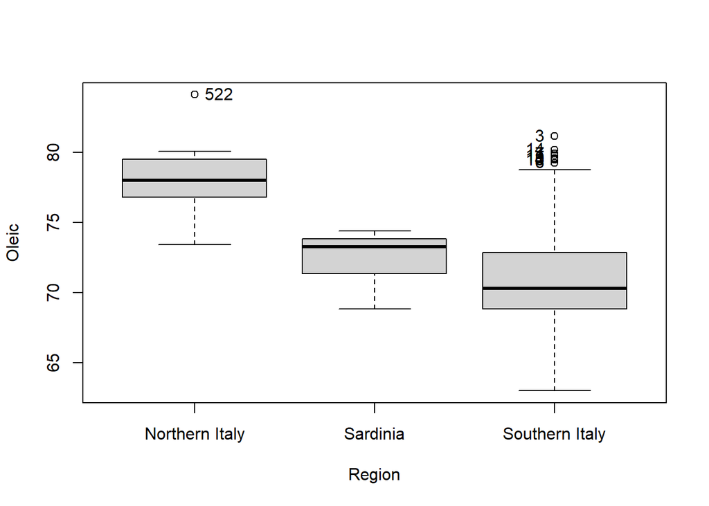

```
## [1] "522" "3"   "4"   "6"   "7"   "10"  "11"  "14"  "19"
```

```r
Boxplot(olive$oleic, olive$region, xlab = "Region", ylab = "Oleic")
```

### Ejercicio 2

**Ejercicio 2.1**  
Determine la media, la mediana, la moda y la desviación estándar de cada una de las variables. Se puede calcular a todas la variables? a cuales no? Justifique su respuesta

```r
a = mtcars
head(a)
```

```
##                    mpg cyl disp  hp drat    wt  qsec vs am gear carb
## Mazda RX4         21.0   6  160 110 3.90 2.620 16.46  0  1    4    4
## Mazda RX4 Wag     21.0   6  160 110 3.90 2.875 17.02  0  1    4    4
## Datsun 710        22.8   4  108  93 3.85 2.320 18.61  1  1    4    1
## Hornet 4 Drive    21.4   6  258 110 3.08 3.215 19.44  1  0    3    1
## Hornet Sportabout 18.7   8  360 175 3.15 3.440 17.02  0  0    3    2
## Valiant           18.1   6  225 105 2.76 3.460 20.22  1  0    3    1
```

```r
summary(a)
```

```
##       mpg             cyl             disp             hp
##  Min.   :10.40   Min.   :4.000   Min.   : 71.1   Min.   : 52.0
##  1st Qu.:15.43   1st Qu.:4.000   1st Qu.:120.8   1st Qu.: 96.5
##  Median :19.20   Median :6.000   Median :196.3   Median :123.0
##  Mean   :20.09   Mean   :6.188   Mean   :230.7   Mean   :146.7
##  3rd Qu.:22.80   3rd Qu.:8.000   3rd Qu.:326.0   3rd Qu.:180.0
##  Max.   :33.90   Max.   :8.000   Max.   :472.0   Max.   :335.0
##       drat             wt             qsec             vs
##  Min.   :2.760   Min.   :1.513   Min.   :14.50   Min.   :0.0000
##  1st Qu.:3.080   1st Qu.:2.581   1st Qu.:16.89   1st Qu.:0.0000
##  Median :3.695   Median :3.325   Median :17.71   Median :0.0000
##  Mean   :3.597   Mean   :3.217   Mean   :17.85   Mean   :0.4375
##  3rd Qu.:3.920   3rd Qu.:3.610   3rd Qu.:18.90   3rd Qu.:1.0000
##  Max.   :4.930   Max.   :5.424   Max.   :22.90   Max.   :1.0000
##        am              gear            carb
##  Min.   :0.0000   Min.   :3.000   Min.   :1.000
##  1st Qu.:0.0000   1st Qu.:3.000   1st Qu.:2.000
##  Median :0.0000   Median :4.000   Median :2.000
##  Mean   :0.4062   Mean   :3.688   Mean   :2.812
##  3rd Qu.:1.0000   3rd Qu.:4.000   3rd Qu.:4.000
##  Max.   :1.0000   Max.   :5.000   Max.   :8.000
```

```r
#Variable mpg:
# Media = 20.09
# Mediana = 19.20
# Moda = 10.4
# Desviación estandar = 6.026948
freq_ord=sort(table(a$mpg),decreasing = TRUE);
sd(a$mpg)
```

```
## [1] 6.026948
```

```r
#Variable cyl:
# Media = 6.188
# Mediana = 6.000
# Moda = 8
# Desviación estandar = 1.785922
freq_ord=sort(table(a$cyl),decreasing = TRUE);
sd(a$cyl)
```

```
## [1] 1.785922
```

```r
#Variable disp:
# Media = 230.7
# Mediana = 196.3
# Moda = 275.8
# Desviación estandar = 123.9387
freq_ord=sort(table(a$disp),decreasing = TRUE);
sd(a$disp)
```

```
## [1] 123.9387
```

```r
#Variable hp:
# Media = 146.7
# Mediana = 123.0
# Moda = 110
# Desviación estandar = 68.56287
freq_ord=sort(table(a$hp),decreasing = TRUE);
sd(a$hp)
```

```
## [1] 68.56287
```

```r
#Variable drat:
# Media = 3.597
# Mediana = 3.695
# Moda = 3.07
# Desviación estandar = 0.5346787
freq_ord=sort(table(a$drat),decreasing = TRUE);
sd(a$drat)
```

```
## [1] 0.5346787
```

```r
#Variable wt:
# Media = 3.217
# Mediana = 3.325
# Moda = 3.44
# Desviación estandar = 0.9784574
freq_ord=sort(table(a$wt),decreasing = TRUE);
sd(a$wt)
```

```
## [1] 0.9784574
```

```r
#Variable qsec:
# Media = 17.85
# Mediana = 17.71
# Moda = 17.02
# Desviación estandar = 1.786943
freq_ord=sort(table(a$qsec),decreasing = TRUE);
sd(a$qsec)
```

```
## [1] 1.786943
```

```r
#Variable vs: Esta variable es de Bernulli, por lo que no se le puede calcular la media ni la mediana
# Media =
# Mediana =
# Moda = 0
# Desviación estandar =
freq_ord=sort(table(a$vs),decreasing = TRUE);
sd(a$vs)
```

```
## [1] 0.5040161
```

```r
#Variable am:Esta variable es de Bernulli, por lo que no se le puede calcular la media ni la mediana
# Media =
# Mediana =
# Moda = Transmision automatica (0)
# Desviación estandar =
freq_ord=sort(table(a$am),decreasing = TRUE);
sd(a$am)
```

```
## [1] 0.4989909
```

```r
#Variable gear:
# Media = 3.688
# Mediana = 4.000
# Moda = 3
# Desviación estandar = 0.7378041
freq_ord=sort(table(a$gear),decreasing = TRUE);
sd(a$gear)
```

```
## [1] 0.7378041
```

```r
#Variable carb:
# Media = 2.812
# Mediana = 2.000
# Moda = 2
# Desviación estandar = 1.6152
freq_ord=sort(table(a$carb),decreasing = TRUE);
sd(a$carb)
```

```
## [1] 1.6152
```

**Ejercicio 2.2**  
Determinar qué variable presenta valores atípicos, ¿cómo los ha encontrado?

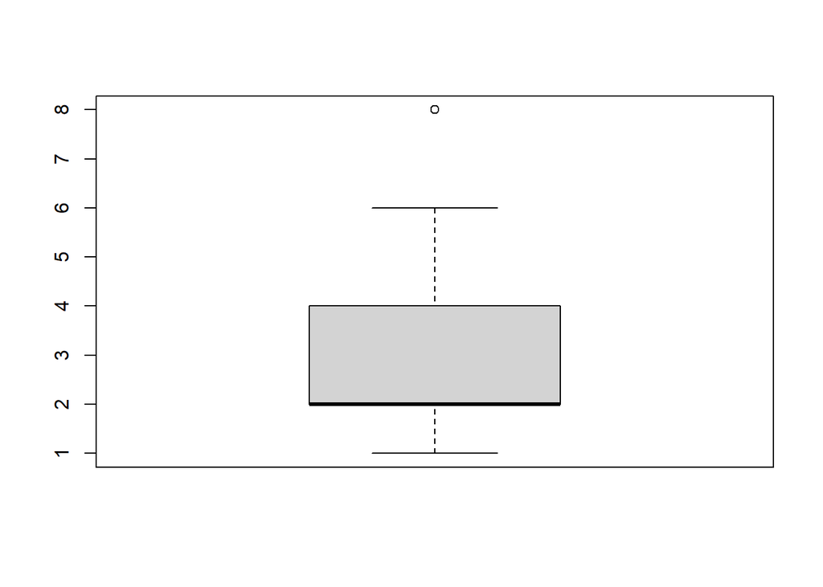

```r
boxplot(a$carb)
```

Variables con valores atípicos: hp, wt, qsec, carb. Las hallamos usando boxplot.

**Ejercico 2.3**  
Hacer el histograma para cada una de las variable usando 5 intervalos. De nuevo, está gráfica es útil para todas las variables? justifique su respuesta.

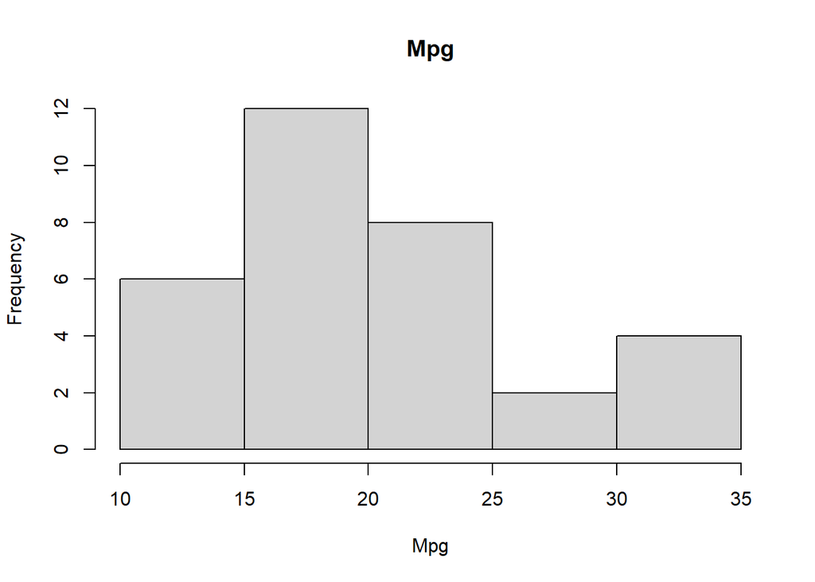

```r
#Histograma mpg
hist(a$mpg, main = "Mpg", xlab = "Mpg", breaks = 5)
```

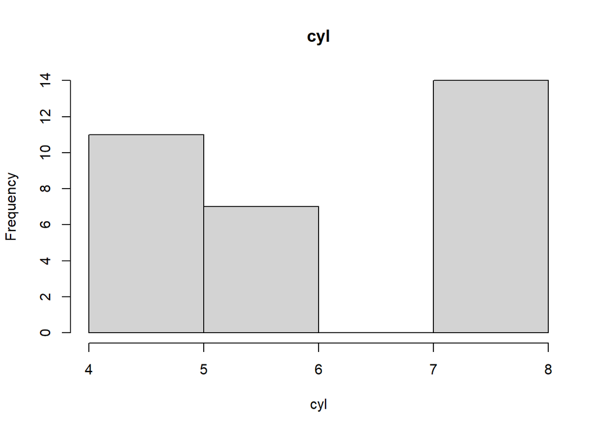

```r
#Histograma cyl
hist(a$cyl, main = "cyl", xlab = "cyl", breaks = 5)
```

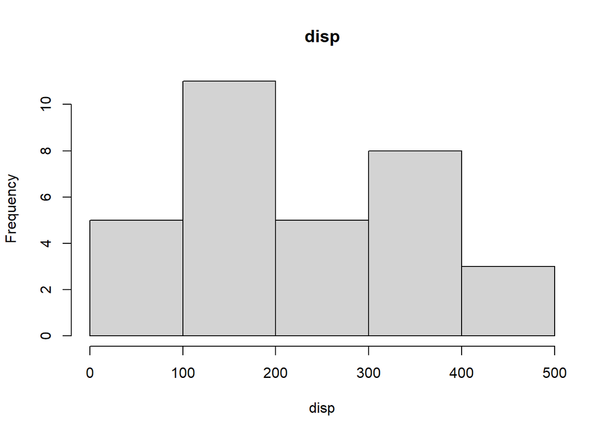

```r
#Histograma disp
hist(a$disp, main = "disp", xlab = "disp", breaks = 5)
```

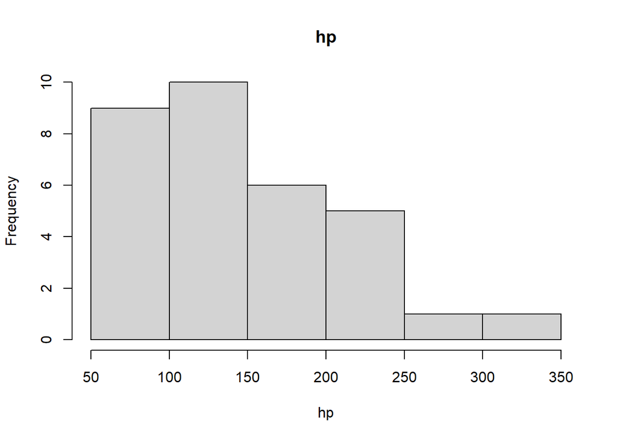

```r
#Histograma hp
hist(a$hp, main = "hp", xlab = "hp", breaks = 5)
```

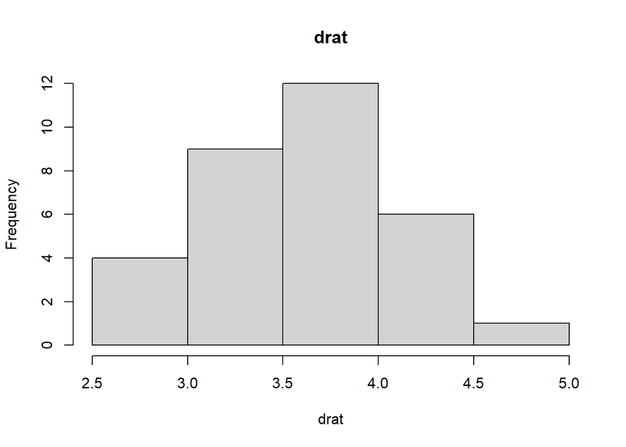

```r
#Histograma drat
hist(a$drat, main = "drat", xlab = "drat", breaks = 5)
```

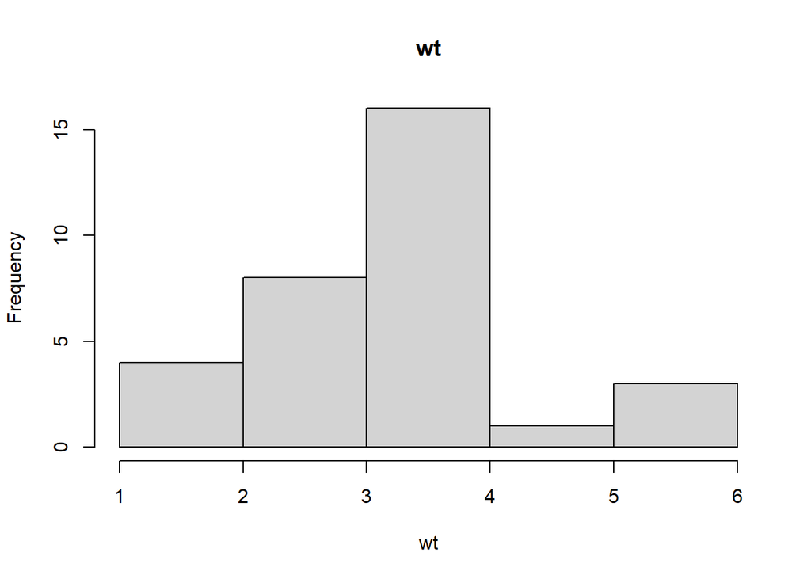

```r
#Histograma wt
hist(a$wt, main = "wt", xlab = "wt", breaks = 5)
```

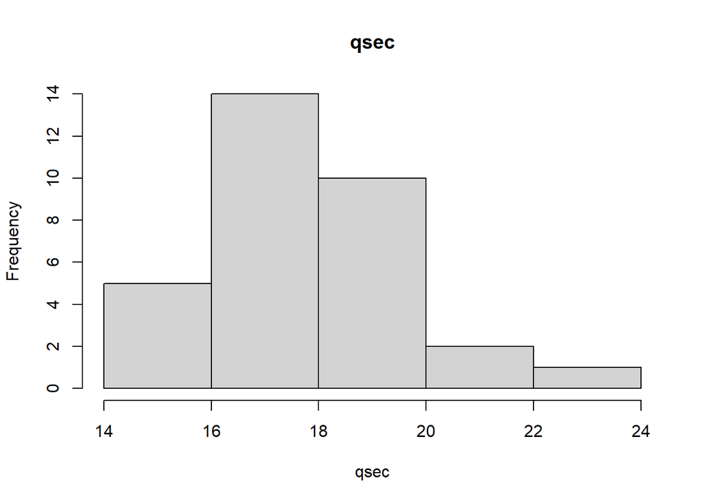

```r
#Histograma qsec
hist(a$qsec, main = "qsec", xlab = "qsec", breaks = 5)
```

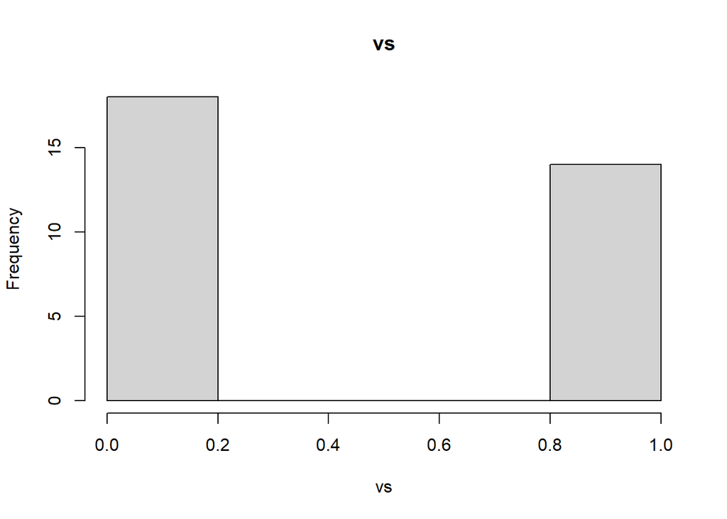

```r
#Histograma vs
hist(a$vs, main = "vs", xlab = "vs", breaks = 5)
```

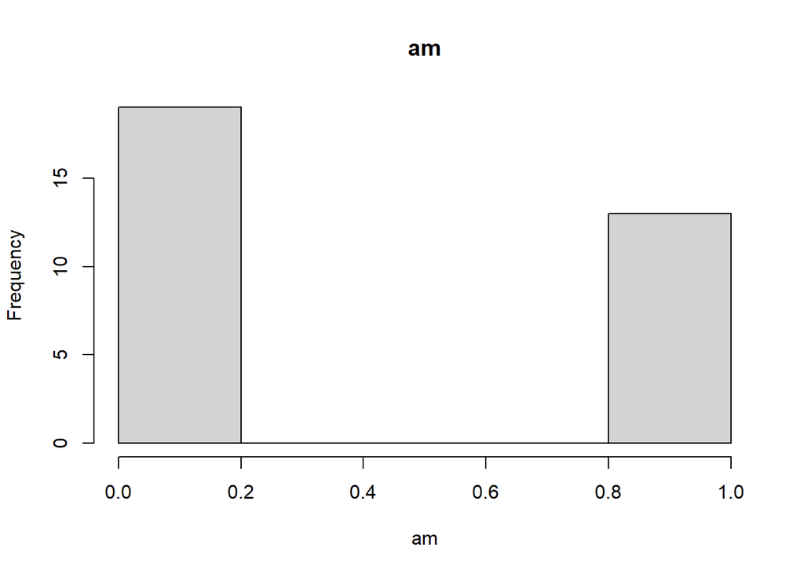

```r
#Histograma am
hist(a$am, main = "am", xlab = "am", breaks = 5)
```

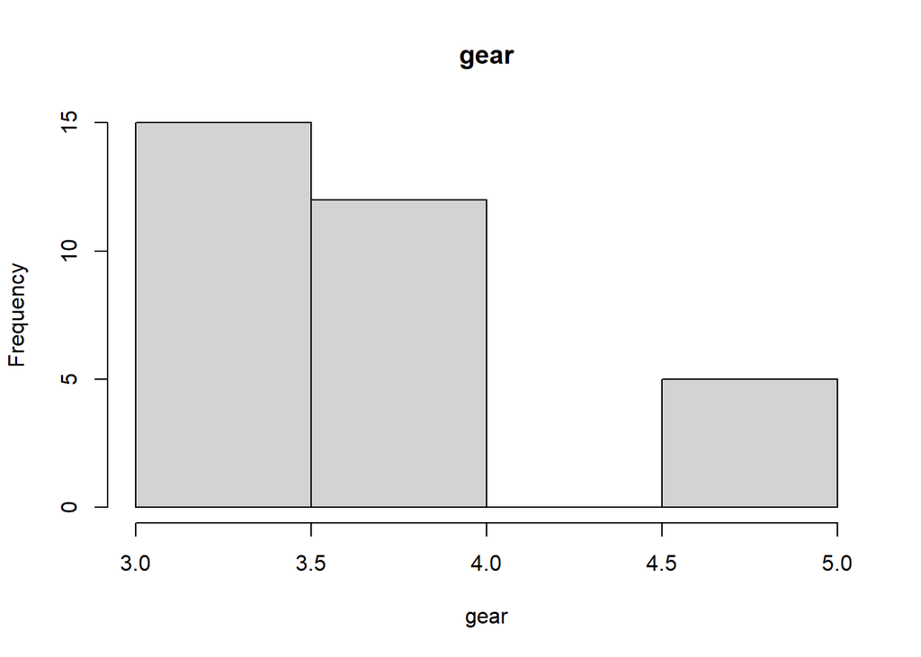

```r
#Histograma gear
hist(a$gear, main = "gear", xlab = "gear", breaks = 5)
```

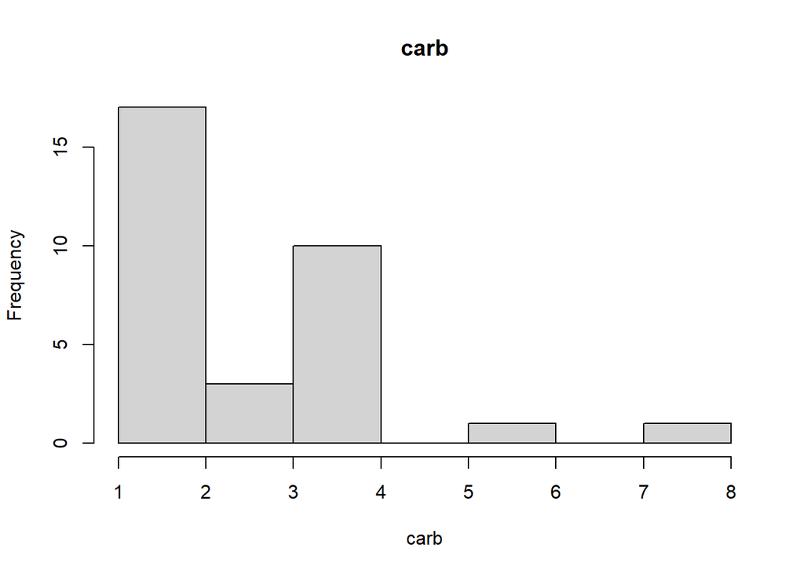

```r
#Histograma carb
hist(a$carb, main = "carb", xlab = "carb", breaks = 5)
```

Esta gráfica no es util para las variables AM y VS porque solo tienen valores 1 y 0.

**Ejercicio 2.4**  
Realice una gráfica que incluya el diagrama de cajas de todas las variables de tal manera de que se puedan comparar.

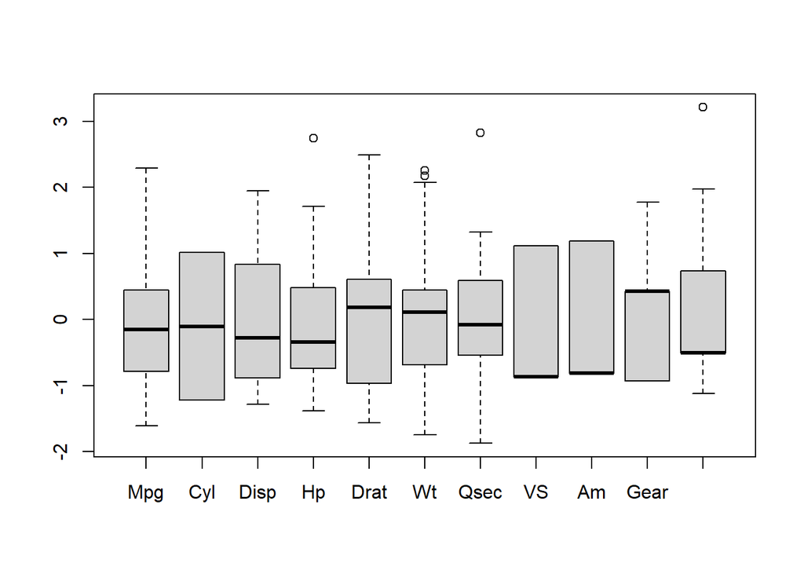

```r
# Normalizamos el vector que contiene
# las observaciones de mpg
vec_mpg = a$mpg
sd_mpg = sd(vec_mpg)
mn_mpg = mean(vec_mpg)
mn_vec_mpg= rep(c(mn_mpg), each=length(vec_mpg))
nor_vec_mpg = (1/sd_mpg)*(vec_mpg - mn_vec_mpg)
#boxplot(nor_vec_mpg, main="Mpg")

# Normalizamos el vector que contiene
# las observaciones de cyl
vec_cyl = a$cyl
sd_cyl = sd(vec_cyl)
mn_cyl = mean(vec_cyl)
mn_vec_cyl= rep(c(mn_cyl), each=length(vec_cyl))
nor_vec_cyl = (1/sd_cyl)*(vec_cyl - mn_vec_cyl)
#boxplot(nor_vec_cyl, main="cyl")

# Normalizamos el vector que contiene
# las observaciones de disp
vec_disp = a$disp
sd_disp = sd(vec_disp)
mn_disp = mean(vec_disp)
mn_vec_disp= rep(c(mn_disp), each=length(vec_disp))
nor_vec_disp = (1/sd_disp)*(vec_disp - mn_vec_disp)
#boxplot(nor_vec_disp, main="disp")

# Normalizamos el vector que contiene
# las observaciones de hp
vec_hp = a$hp
sd_hp = sd(vec_hp)
mn_hp = mean(vec_hp)
mn_vec_hp= rep(c(mn_hp), each=length(vec_hp))
nor_vec_hp = (1/sd_hp)*(vec_hp - mn_vec_hp)
#boxplot(nor_vec_hp, main="hp")

# Normalizamos el vector que contiene
# las observaciones de drat
vec_drat = a$drat
sd_drat = sd(vec_drat)
mn_drat = mean(vec_drat)
mn_vec_drat= rep(c(mn_drat), each=length(vec_drat))
nor_vec_drat = (1/sd_drat)*(vec_drat - mn_vec_drat)
#boxplot(nor_vec_drat, main="drat")

# Normalizamos el vector que contiene
# las observaciones de wt
vec_wt = a$wt
sd_wt = sd(vec_wt)
mn_wt = mean(vec_wt)
mn_vec_wt= rep(c(mn_wt), each=length(vec_wt))
nor_vec_wt = (1/sd_wt)*(vec_wt - mn_vec_wt)
#boxplot(nor_vec_wt, main="wt")

# Normalizamos el vector que contiene
# las observaciones de qsec
vec_qsec = a$qsec
sd_qsec = sd(vec_qsec)
mn_qsec = mean(vec_qsec)
mn_vec_qsec= rep(c(mn_qsec), each=length(vec_qsec))
nor_vec_qsec = (1/sd_qsec)*(vec_qsec - mn_vec_qsec)
#boxplot(nor_vec_qsec, main="qsec")

# Normalizamos el vector que contiene
# las observaciones de vs
vec_vs = a$vs
sd_vs = sd(vec_vs)
mn_vs = mean(vec_vs)
mn_vec_vs= rep(c(mn_vs), each=length(vec_vs))
nor_vec_vs = (1/sd_vs)*(vec_vs - mn_vec_vs)
#boxplot(nor_vec_vs, main="vs")

# Normalizamos el vector que contiene
# las observaciones de am
vec_am = a$am
sd_am = sd(vec_am)
mn_am = mean(vec_am)
mn_vec_am= rep(c(mn_am), each=length(vec_am))
nor_vec_am = (1/sd_am)*(vec_am - mn_vec_am)
#boxplot(nor_vec_am, main="am")

# Normalizamos el vector que contiene
# las observaciones de gear
vec_gear = a$gear
sd_gear = sd(vec_gear)
mn_gear = mean(vec_gear)
mn_vec_gear= rep(c(mn_gear), each=length(vec_gear))
nor_vec_gear = (1/sd_gear)*(vec_gear - mn_vec_gear)
#boxplot(nor_vec_gear, main="gear")

# Normalizamos el vector que contiene
# las observaciones de carb
vec_carb = a$carb
sd_carb = sd(vec_carb)
mn_carb = mean(vec_carb)
mn_vec_carb= rep(c(mn_carb), each=length(vec_carb))
nor_vec_carb = (1/sd_carb)*(vec_carb - mn_vec_carb)
#boxplot(nor_vec_carb, main="carb")

#Juntamos todos
cols = c("Mpg", "Cyl", "Disp", "Hp", "Drat", "Wt", "Qsec", "VS", "Am", "Gear", "Carb")
boxplot(nor_vec_mpg, nor_vec_cyl, nor_vec_disp, nor_vec_hp, nor_vec_drat, nor_vec_wt,nor_vec_qsec, nor_vec_vs, nor_vec_am, nor_vec_gear, nor_vec_carb, names = cols)
```

### Ejercicio 3

Graficar una matrix de dispersion de tres variables del dataset olive, con la diagonal mostrando boxplots de las variables.

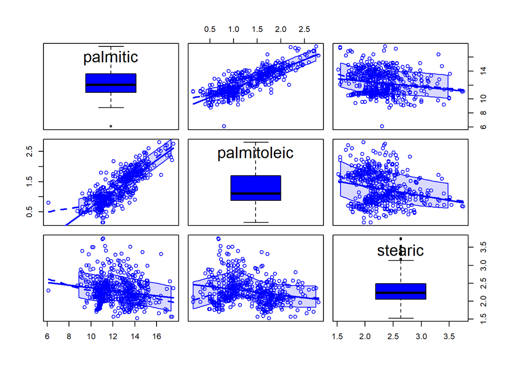

```r
olive_acids <- subset(olive, select = c(-region, -area, -oleic, -linoleic, -linolenic, -arachidic, -eicosenoic))
scatterplotMatrix(~ +., data = olive_acids, diagonal=list(method ="boxplot"))
```

### Ejercicio 4

Graficar un diagrama de dispersión en 3D, de tres variables numéricas del dataset olive graficando en colores diferentes las regiones.

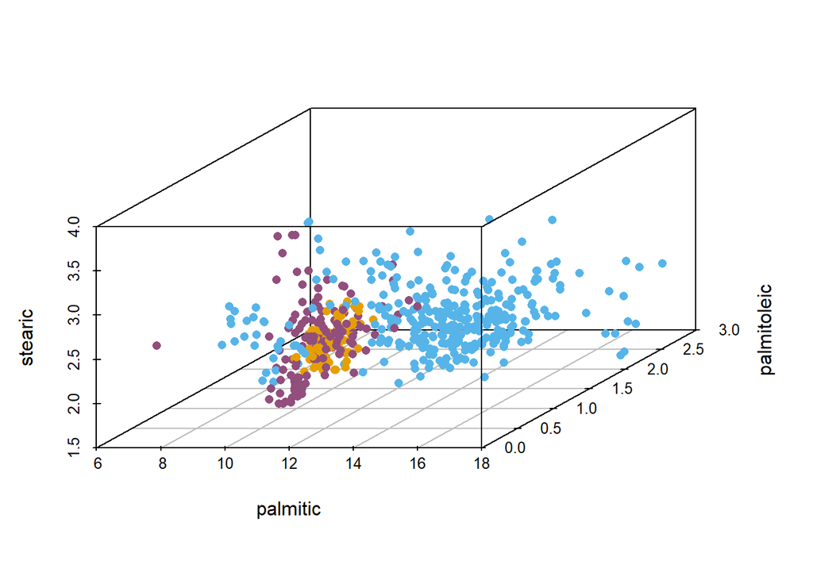

```r
colors <- c("#924e7d", "#E69F00", "#56B4E9")
colors <- colors[as.numeric(olive$region)]
scatterplot3d(olive$palmitic,olive$palmitoleic,olive$stearic,pch = 16, color=colors,
              xlab="palmitic", ylab="palmitoleic", zlab="stearic")
```

### Ejercicio 5

```r
x1 = c(-6, -3, -2, 1, 2, 5, 6, 8)
x2 = c(-2, -3, 1, -1, 2, 1, 5, 3)
```

**Ejercicio 5.a**  
Grafique los datos como un diagrama de dispersión y calcule s11, s22 y s12.

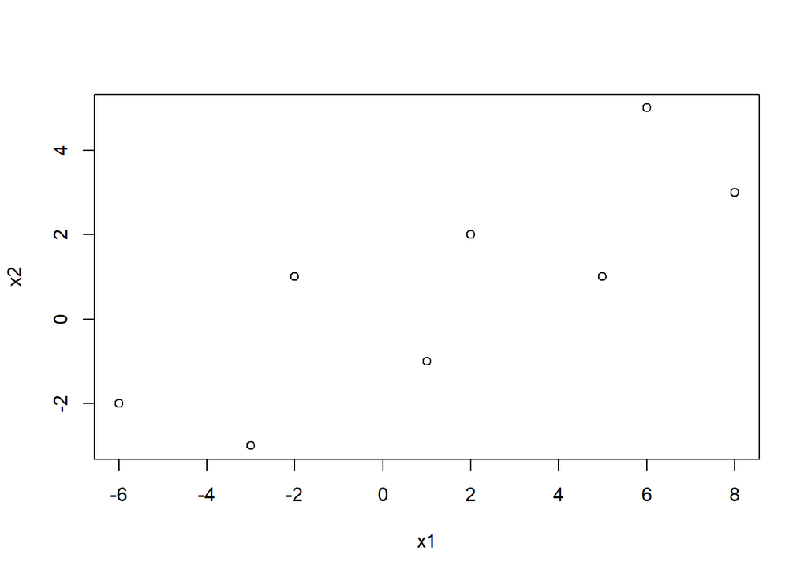

```r
plot(x1, x2, xlab = "x1", ylab = "x2")
```

```r
s11 = (1/length(x1))*sum((x1-mean(x1))^2)
s11
```

```
## [1] 20.48438
```

```r
s22 = (1/length(x2))*sum((x2-mean(x2))^2)
s22
```

```
## [1] 6.1875
```

```r
s12 = (1/length(x1))*sum((x1-mean(x1))*(x2-mean(x2)))
s12
```

```
## [1] 9.09375
```

**Ejercicio 5.b**  
Usando x˜1 = x1 cos(θ) + x2 sin(θ) y x˜2 = −x1 sin(θ) + x2 cos(θ), calcule las medidas correspondientes sobre las variables xe1 y xe2, asumiendo que los ejes coordenados originales están rotados un ángulo de θ = 26 grados.

```r
cos_26 = cos(pi*26/180)
sin_26 = sin(pi*26/180)
x1_barra = x1*cos_26 + x2*sin_26
x1_barra
```

```
## [1] -6.2695066 -4.0114956 -1.3592169  0.4604229  2.6743304  4.9323414  7.5846200
## [8]  8.5054658
```

```r
x2_barra = -1*x1*sin_26 + x2*cos_26
x2_barra
```

```
## [1]  0.8326388 -1.3812687  1.7755363 -1.3371652  0.9208458 -1.2930617  1.8637434
## [8] -0.8105870
```

```r
summary(x1_barra)
```

```
##    Min. 1st Qu.  Median    Mean 3rd Qu.    Max.
##  -6.270  -2.022   1.567   1.565   5.595   8.505
```

```r
summary(x2_barra)
```

```
##     Min.  1st Qu.   Median     Mean  3rd Qu.     Max.
## -1.38127 -1.30409  0.01103  0.07134  1.13452  1.86374
```

**Ejercicio 5.c**  
Usando las medidas x˜1 y x˜2 de (b), calcule las varianzas de muestra se11 y se22

```r
s11_barra = (1/length(x1_barra))*sum((x1_barra-mean(x1_barra))^2)
s11_barra
```

```
## [1] 24.90293
```

```r
s22_barra = (1/length(x2_barra))*sum((x2_barra-mean(x2_barra))^2)
s22_barra
```

```
## [1] 1.768947
```

**Ejercicio 5.d**

```r
x1_5 = 4
x2_5 = -2

x1_5_barra = x1_5*cos_26+x2_5*sin_26
x2_5_barra = -x1_5*sin_26+x2_5*cos_26

d = sqrt(((x1_5_barra)^2/s11_barra)+((x2_5_barra)^2/s22_barra))
d
```

```
## [1] 2.724949
```

**Ejercicio 5.e**

```r
a11 = ((cos_26^2) / ((cos_26^2*s11)+(2*sin_26*cos_26*s12)+(sin_26^2*s22))) + ((sin_26^2)/((cos_26^2)*s22-2*sin_26*cos_26*s12+(sin_26^2)*s11))
a22 = ((sin_26^2)/(cos_26^2*s11+2*sin_26*cos_26*s12+sin_26^2*s22)) + ((cos_26^2)/(cos_26^2*s22-2*sin_26*cos_26*s12+sin_26^2*s11))
a12 = ((cos_26*sin_26)/(cos_26^2*s11+2*sin_26*cos_26*s12+sin_26^2*s22)) - ((sin_26*cos_26)/(cos_26^2*s22-2*sin_26*cos_26*s12+sin_26*s11))

d_5_e = sqrt(a11*(x1_5^2)+2*a12*x1_5*x2_5+a22*x2_5^2)
# En este punto es importante reconocer que no tenemos el mismo resultado, sin embargo, no pudimos encontrar el error.
d_5_e
```

```
## [1] 2.187922
```

### Ejercicio 6

**Ejercicio 6.a**  
Sea X = $(x_{1},x_{2})$, $\tilde{x}_{1} = x_1 cos(\theta)+x_2 sen(\theta)$, $\tilde{x}_{2} = -x_1 sen(\theta)+x_2 cos(\theta)$. Se tiene que la distancia estadística $d(0,x) = \sqrt{a_{11} x_1^2 + 2a_{12}x_1 x_2 + a_{22}x_2^2}$ donde $a_{ij}$ son funciones de $\theta$. Si asumimos que $a_{11} = 1, a_{22}=4, a_{12}=\frac{1}{2}$ se tiene que $d(0,X) = \sqrt{x_1^2+\frac{1}{2}2x_1 x_2 + 4 x_2^2}$. Y $d(0,X)^2 = x_1^2+x_1 x_2 + 4 x_2^2$. Por lo tanto, la primera función es válida.  
**Ejercicio 6.b**  
De forma equivalente al ejercicio 6.a, dado que $a_{12} \neq 0$, la segunda función no es válida.

### Ejercicio 7

Muestre que la matriz de correlación muestral también se puede obtener como la matrix de covarianza de las observaciones estandarizadas.

Sean S la matriz de varianzas y covarianzas, donde $S_{ik} = \frac{1}{n}\sum_{j=1}^{n}(x_{ji}-\overline{x}_i)(x_{jk}-\overline{x}_k)$. Reemplazando los valores $x_{ji}$ y $x_{jk}$ por valores estandarizados $(x_{ji}-\overline{x}_i)/\sqrt{S_{ii}}$ y $(x_{jk}-\overline{x}_k)/\sqrt{S_{kk}}$, respectivamente. Se tiene $\\S_{ik} = \frac{1}{n}\sum_{j=1}^{n}((x_{ji}-\overline{x}_i)/\sqrt{S_{ii}})((x_{jk}-\overline{x}_k)/\sqrt{S_{kk}})\\$  
$= \frac{\frac{1}{n}\sum_{j=1}^{n}(x_{ji}-\overline{x}_i)(x_{jk}-\overline{x}_k)}{\sqrt{S_{ii}}\sqrt{S_{kk}}} = \frac{S_{ik}}{\sqrt{S_{ii}}\sqrt{S_{kk}}} = r_{ik}$  
Por lo tanto, matriz de correlación muestral también se puede obtener como la matrix de covarianza de las observaciones estandarizadas.